# Excercise Prediction

Ilia Ershov

June 20, 2016

## Introduction

This work investigates the way to predict the manner in which people perform the excercises using the data collected by the personal measurement devices.

## Reading and preparing the data

First, let us download and read the data. Some of the fields have `#DIV/0!` instead of real values, and in this work this errors will be interpreted as NA.

```r
if(!file.exists("pml-training.csv")){
  download.file("https://d396qusza40orc.cloudfront.net/predmachlearn/pml-training.csv", destfile="pml-training.csv")
}

if(!file.exists("pml-testing.csv")){
  download.file("https://d396qusza40orc.cloudfront.net/predmachlearn/pml-testing.csv", destfile="pml-testing.csv")
}

training <- read.csv("pml-training.csv", na.strings = c("NA", "#DIV/0!"))
testing <- read.csv("pml-testing.csv", na.strings = c("NA", "#DIV/0!"))
```

This data set lots of variables that could be predictors and one outcome variable for the training data - `classe`. Not all of the variables can or should be used for the prediction - some of it is the number of the current measurements, timestamps, usernames or measurement window numbers, which should not be used for prediction:

```r
head(names(training), 7)
```

```
## [1] "X"                    "user_name"            "raw_timestamp_part_1"
## [4] "raw_timestamp_part_2" "cvtd_timestamp"       "new_window"
## [7] "num_window"
```

Lots of variables have always or almost always empty values, and can’t be used at all:

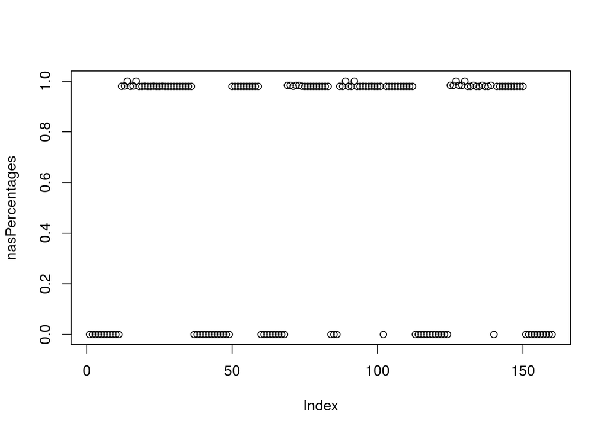

```r
variablesCount <- dim(training)[2]
nasPercentages <- sapply(1:variablesCount, function(x) {mean(is.na(training[,x]))})

plot(nasPercentages)
```

Let’s filter out variables then and only use variables that always have values and are not user name/measurement number/etc.

```r
trainingFiltered <- training[,nasPercentages == 0]
trainingFiltered <- trainingFiltered[,-(1:7)]
```

We need to split the data to the training and the validation set to implement the cross-validation. Let’s use 80% of the rows as a training set.

```r
library(ggplot2)
library(lattice)
library(caret)

set.seed(31337)
inTrain <- createDataPartition(y = trainingFiltered$classe, p = .8, list = FALSE)

validation <- trainingFiltered[-inTrain,]
trainingFiltered <- trainingFiltered[inTrain,]
```

## Fitting the model

There are lots of the available models to available for predicting the outcome of a factor variable, and it turns out the random forests model provides pretty good results with the error rate is lower than 1%.

```r
fit <- train(classe ~ ., data = trainingFiltered, method = "rf", verbose = FALSE)
validation$predictedRF <- predict(fit, validation)
mean(validation$predictedRF != validation$classe)
```

```
## [1] 0.006882488
```

## Results

```r
testing$predicted <- predict(fit, testing)
```

The values for these 20 items are:

```r
testing$predicted
```

```
##  [1] B A B A A E D B A A B C B A E E A B B B
## Levels: A B C D E
```